# Tuneando (un poco) los Rmd’s

Pedro J. Pérez

25 mayo 2022

## 1. Cosas/Mundillo R

Este mes se celebra el [#30DayMapChallenge](https://twitter.com/search?q=%2330DayMapChallenge&src=hashtag_click). Mirad que mapas!!

##### Pedazo de mapa

y relativamente sencillo

> A map for this week's [#TidyTuesday](https://twitter.com/hashtag/TidyTuesday?src=hash&ref_src=twsrc%5Etfw), showing life expectancy on the globe.  
> code: https://t.co/sOIqzOubKF  
> [#Rstats](https://twitter.com/hashtag/Rstats?src=hash&ref_src=twsrc%5Etfw) [#dataviz](https://twitter.com/hashtag/dataviz?src=hash&ref_src=twsrc%5Etfw) [pic.twitter.com/kzWUpBbfnm](https://t.co/kzWUpBbfnm)

> — Georgios Karamanis (@geokaramanis) [November 6, 2021](https://twitter.com/geokaramanis/status/1456970691773976578?ref_src=twsrc%5Etfw)

##### Otro pedazo de mapa

Esta vez un poco mucho-más complicado

> [#30DayMapChallenge](https://twitter.com/hashtag/30DayMapChallenge?src=hash&ref_src=twsrc%5Etfw)  
> Day 6: Red  
> My home city Cuenca is characterized by its red rooftops!  
> 📌-2.9004, -79.0069  
> For the next 3 days I will go with RGB composites of [#Sentinel2](https://twitter.com/hashtag/Sentinel2?src=hash&ref_src=twsrc%5Etfw)  
> Created with {rgee}, {tmap} & {osmdata} in [#RStats](https://twitter.com/hashtag/RStats?src=hash&ref_src=twsrc%5Etfw)  
> Code: https://t.co/FtFw48aRSC [pic.twitter.com/cV0KICarEz](https://t.co/cV0KICarEz)

> — Lorena Abad (@loreabad6) [November 6, 2021](https://twitter.com/loreabad6/status/1456955289148829697?ref_src=twsrc%5Etfw)

##### Otro más!!!

parece complicado pero relativamente easy

> Here is my map for Day 9 (Monochrome) of the [#30DayMapChallenge](https://twitter.com/hashtag/30DayMapChallenge?src=hash&ref_src=twsrc%5Etfw). Mapping 5 different cities by bike lanes, train lines, water and other features. Best when viewed full.  
> Code: https://t.co/G4EzJTQBxC  
> Full Image: https://t.co/iZjlsG5iVU[#rstats](https://twitter.com/hashtag/rstats?src=hash&ref_src=twsrc%5Etfw) [#dataviz](https://twitter.com/hashtag/dataviz?src=hash&ref_src=twsrc%5Etfw) [#r4ds](https://twitter.com/hashtag/r4ds?src=hash&ref_src=twsrc%5Etfw) [#tidyverse](https://twitter.com/hashtag/tidyverse?src=hash&ref_src=twsrc%5Etfw) [#ggplot2](https://twitter.com/hashtag/ggplot2?src=hash&ref_src=twsrc%5Etfw) [pic.twitter.com/8yqODMzJsw](https://t.co/8yqODMzJsw)

> — Blake Robert Mills (@BlakeRobMills) [November 10, 2021](https://twitter.com/BlakeRobMills/status/1458415001098665985?ref_src=twsrc%5Etfw)
- Ya sabéis que este mes se celebra el [30 Day Map Challenge](https://david.frigge.nz/3RDayMapChallenge/). David Fringe ha creado esta [fantástica galería](https://david.frigge.nz/3RDayMapChallenge/maps.html) de mapas con su código
- El paquete hockeystick facilita el uso de datos relacionados con el cambio climático.
- El paquete geodata facilita la bajada de datos de temperatura, elevación y muchas otras cosas. Un ejemplo [aquí](https://twitter.com/loreabad6/status/1458747576455475210), el código [aquí](https://github.com/loreabad6/30DayMapChallenge/blob/main/scripts/day10_raster.R)
- Un [ejemplo de trabajo](https://nearanddistant.medium.com/the-divided-kingdom-the-uks-north-south-divide-is-the-most-unequal-in-the-developed-world-d6ca5c972943). El código está [aquí](https://github.com/NearAndDistant/ruk/tree/main/projects/ons_region_gdhi_1997_2018)

## 2. Otros formatos de salida

### 2.A Vamos a probar a hacer

- Un **póster** con posterdown o con [pagedown::poster_relaxed](https://github.com/rstudio/pagedown#resume-pagedownhtml_resume).
- Unas **slides** con `ioslides`. Dos ejemplos [aquí](https://nosan5.github.io/trabajo_BigData_slides/#1) y [aquí](https://manujimenez62.github.io/trabajo_BigData_slides/#1). Dos tutoriales, [aquí](https://garrettgman.github.io/rmarkdown/ioslides_presentation_format.html) y [aquí](https://bookdown.org/yihui/rmarkdown/ioslides-presentation.html)
- Un **currículum** con [pagedown::html_resume](https://github.com/rstudio/pagedown#resume-pagedownhtml_resume).
- **Business cards** con [pagedown::business_card](https://github.com/rstudio/pagedown#business-cards-pagedownbusiness_card)
- **“Cuadros de mando”**] con [flexdashboard](https://pkgs.rstudio.com/flexdashboard/): tienes algunos ejemplos [aquí](https://pkgs.rstudio.com/flexdashboard/articles/examples.html). Permite [distintos layouts](https://pkgs.rstudio.com/flexdashboard/articles/layouts.html), incluidos los storyboards, por ejemplo [este](https://beta.rstudioconnect.com/jjallaire/htmlwidgets-showcase-storyboard/htmlwidgets-showcase-storyboard.html)
- **Shiny apps** con el paquete [shiny](https://shiny.rstudio.com/): algunos [ejemplos](https://shiny.rstudio.com/gallery/)
- **Scrollama** documents for storytelling con el paquete rolldown

### 2.B Otros formatos

- Formatos posibles gracias al paquete rmdformats
- El paquete [paralax](https://github.com/martinctc/parallaxr) permite obtener un output muy chulo para contar historias. Mira [este ejemplo](https://martinctc.github.io/examples/parallaxr-examples-output.html). El código que genera el anterior documento está [aquí](https://github.com/martinctc/parallaxr/blob/main/examples/demo%20script.R). No es difícil, pero …

## 3. Tuneado documentos Rmd

### 3.A theme y sintax predefinidos

- En el yaml puedes cambiar el parámetro **`theme`**. Tienes disponibles lo siguientes temas: `default, bootstrap, cerulean, cosmo, darkly` `flatly, journal, lumen, paper, readable, sandstone, simplex, spacelab, united, yeti`.
- En el yaml también puedes cambiar el parámetro **`highlighting`**. Tienes las siguientes opciones: `default, tango, pygments, kate, monochrome, espresso, zenburn, haddock, and breezedark`
- Por ejemplo:

```r
---
title: "Guión de clase_09"
author: "Pedro J. Pérez"
date: "Noviembre de 2021"
output:
  html_document:
    toc: yes
    toc_float: yes
    theme: paper
    highlight: textmate
----
```

### 3.B Con el pkg `bslib`

- Recientemente, con el paquete [`bslib`](https://rstudio.github.io/bslib/) se ha facilitado mucho el tuneado de los themes directamente desde R. Puedes aprender cómo [aquí](https://rstudio.github.io/bslib/articles/bslib.html#custom)

```r
---
title: "Guión de clase_09"
author: "Pedro J. Pérez"
date: "Noviembre de 2021"
output:
  html_document:
    theme:
      bg: "#101010"
      fg: "#FDF7F7"
      primary: "#ED79F9"
      base_font:
        google: "Prompt"
      code_font:
        google: "JetBrains Mono"
---
```

Tambíen permite usar los themes de `bootswatch.4`. Si quieres ver como quedan estos themes, puedes verlos [aquí](https://bootswatch.com/4/). Por ejemplo

```r
---
title: "Guión de clase_09"
author: "Pedro J. Pérez"
date: "Noviembre de 2021"
output:
  html_document:
    toc: yes
    toc_float: yes
    theme:
      bootswatch: sketchy
----
```

- El paquete `bslib` tiene una shiny app con la que puedes probar a customizar un documento html. Para ello, sigue la siguiente ruta de menús: `File > New File > Rmarkdow`. Se abrirá una ventana para que elijas el tipo de documento Rmd que quieres. Selecciona `From template`. Se abrira un cuadro donde has de seleccionar `Real-time theming`. Se creará/abrirá un nuevo documento sin mobre (“Untitled1”). PIncha en el icono “Run Document” con flechita verde. Te pedirá que le pongas un nombre. Pónselo. Verás un documento html en el panel derecho-abajo de RStudio. Haz que se vea en el navegador y juega con él.

### 3.C Con CSS

- Veremos un ejemplo con las plantillas de los trabajos

## 4. Rmd: un truquillo chulo

### 3.A: Tabs en Rmd

En Rmd podemos usar “tabs”, para ello has de poner `{.tabset .tabset-pills}` en una sección header y las secciones de un nivel inferior se verán en tabs. Veámoslo:

#### el primer tab (code)

```r
library(ggplot2)
ggplot(iris, aes(Sepal.Length, Petal.Length, color = Species)) +
  geom_point()
```

#### el segundo tab (gráfico)

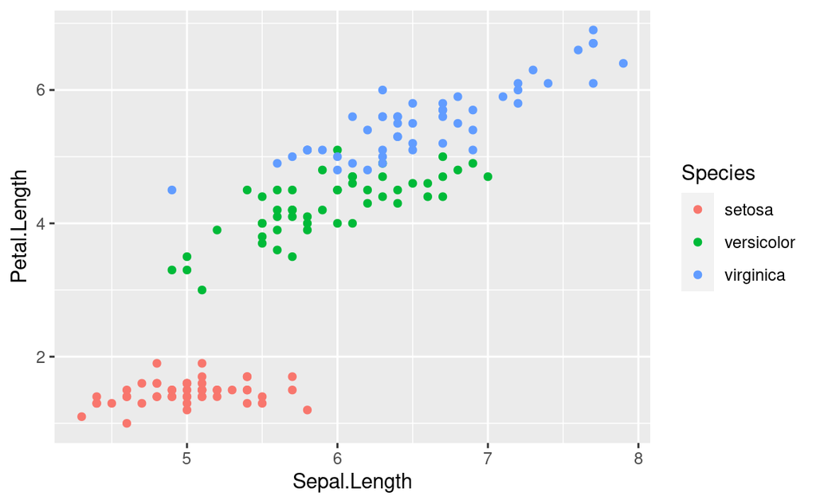

## 5. Paquetes a instalar

```r
pacman::p_install(bslib, thematic, shiny, rmdformats, flexdashboard, posterdown, vitae)
pacman::p_install_gh(c("rstudio/pagedown", "yihui/rolldown"))
```

Tb vamos a instalar tinytext

```r
install.packages("tinytex")
tinytex::install_tinytex()
```